# The most harmful weather events on population and economy of the United States

## Synopsis

This data analysis answers two questions: across the United States:

1. Which types of events are most harmful with respect to population health?
2. Which types of events have the greatest economic consequences?

To answer on this question I analyse U.S. National Oceanic and Atmospheric Administration’s (NOAA) storm database that tracks characteristics of major storms and weather events in the United States between 1950 and November 2011

## Data Analysis

### Prerequisits

```r
library("knitr")
# don't use scientific notation
options(scipen = 6, digits = 3)
# R.utils requires to unzip the data file
library("R.utils")
# ggplot requires to draw graphs
library("ggplot2")
```

### Load NOAA database into R

```r
# download and unpack data from the Internet
download.file("http://d396qusza40orc.cloudfront.net/repdata%2Fdata%2FStormData.csv.bz2",
              destfile = "repdata-data-StormData.csv.bz2")
bunzip2("repdata-data-StormData.csv.bz2", overwrite = TRUE)

# load data into R
data = read.csv("repdata-data-StormData.csv")
```

### Show information over the dataset

```r
# data dimentions
rows <- dim(data)[1]
columns <- dim(data)[2]

# show all columns
colnames(data)
```

```
##  [1] "STATE__"    "BGN_DATE"   "BGN_TIME"   "TIME_ZONE"  "COUNTY"
##  [6] "COUNTYNAME" "STATE"      "EVTYPE"     "BGN_RANGE"  "BGN_AZI"
## [11] "BGN_LOCATI" "END_DATE"   "END_TIME"   "COUNTY_END" "COUNTYENDN"
## [16] "END_RANGE"  "END_AZI"    "END_LOCATI" "LENGTH"     "WIDTH"
## [21] "F"          "MAG"        "FATALITIES" "INJURIES"   "PROPDMG"
## [26] "PROPDMGEXP" "CROPDMG"    "CROPDMGEXP" "WFO"        "STATEOFFIC"
## [31] "ZONENAMES"  "LATITUDE"   "LONGITUDE"  "LATITUDE_E" "LONGITUDE_"
## [36] "REMARKS"    "REFNUM"
```

### Remove unused data

A big dataset with 902297 rows and 37 columns is rather big so I keep the columns I need:

```r
tinyData <- data[,c("EVTYPE", "FATALITIES", "INJURIES", "PROPDMG", "PROPDMGEXP", "CROPDMG", "CROPDMGEXP")]
colnames(tinyData) <- c("EventType", "Fatalities", "Injuries", "PropertyDamage", "PropertyDamageMultiplicator", "CropDamage", "CropDamageMultiplicator")
colnames(tinyData)
```

```
## [1] "EventType"                   "Fatalities"
## [3] "Injuries"                    "PropertyDamage"
## [5] "PropertyDamageMultiplicator" "CropDamage"
## [7] "CropDamageMultiplicator"
```

### Change the data type from strings to numbers

The columns `PropertyDamageMultiplicator` and `CropDamageMultiplicator` have the symbols ‘H’, ‘K’, ‘M’ and ‘B’ instead of numbers 100, 1000, 1000000, 1000000000

```r
summary(tinyData$PropertyDamageMultiplicator)
```

```
##             -      ?      +      0      1      2      3      4      5
## 465934      1      8      5    216     25     13      4      4     28
##      6      7      8      B      h      H      K      m      M
##      4      5      1     40      1      6 424665      7  11330
```

```r
summary(tinyData$CropDamageMultiplicator)
```

```
##             ?      0      2      B      k      K      m      M
## 618413      7     19      1      9     21 281832      1   1994
```

and I replace the symbols with the numbers, multiply and remove the column “…Multiplicator” - for Property Damage

```r
levels(tinyData$PropertyDamageMultiplicator)
levels(tinyData$PropertyDamageMultiplicator)[1:4] <- c("0", "1", "1", "1")
levels(tinyData$PropertyDamageMultiplicator)
levels(tinyData$PropertyDamageMultiplicator)[10:15] <- c("1000000000", "100", "100", "1000", "1000000", "1000000")
levels(tinyData$PropertyDamageMultiplicator)
tinyData$PropertyDamageMultiplicator <- as.integer(as.character(tinyData$PropertyDamageMultiplicator))
tinyData$PropertyDamage <- tinyData$PropertyDamage * tinyData$PropertyDamageMultiplicator
tinyData$PropertyDamageMultiplicator <- NULL
```

- for Crop Damage

```r
levels(tinyData$CropDamageMultiplicator)
levels(tinyData$CropDamageMultiplicator)[1:2] <- c("0", "1")
levels(tinyData$CropDamageMultiplicator)
levels(tinyData$CropDamageMultiplicator)[4:8] <- c("1000000000", "1000", "1000", "1000000", "1000000")
levels(tinyData$CropDamageMultiplicator)
tinyData$CropDamageMultiplicator <- as.integer(as.character(tinyData$CropDamageMultiplicator))
tinyData$CropDamage <- tinyData$CropDamage * tinyData$CropDamageMultiplicator
tinyData$CropDamageMultiplicator <- NULL
```

### Look for the most harmful event on population health

- get sorted summary of fatalities

```r
fatalities <- with(tinyData, aggregate(Fatalities, by = list(EventType), sum))
colnames(fatalities) <- c("EventType", "Fatalities")
fatalities <- fatalities[order(-fatalities$Fatalities),]
```

- get sorted summary of injuries

```r
injuries <- with(tinyData, aggregate(Injuries, by = list(EventType), sum))
colnames(injuries) <- c("EventType", "Injuries")
injuries <- injuries[order(-injuries$Injuries),]
```

- get sorted summary of fatalities and injuries

```r
casualties <- merge(fatalities, injuries, by.y = "EventType")
casualties$Casualties <- casualties$Fatalities + casualties$Injuries
casualties <- casualties[order(-casualties$Casualties),]
```

- get 1% of most harmful events and divide on billion

```r
one <- quantile(casualties$Casualties, c(0, 1, 0.99))[3]
casualties1 <- casualties[casualties$Casualties > one,]
row.names(casualties1) <- NULL
casualties1
```

[output not shown]

### Look for the most harmful event with the greatest economic consequences

- get sorted summary of property damage

```r
propertyDamage <- with(tinyData, aggregate(PropertyDamage, by = list(EventType), sum))
colnames(propertyDamage) <- c("EventType", "PropertyDamage")
propertyDamage <- propertyDamage[order(-propertyDamage$PropertyDamage),]
```

- get sorted summary of crop damage

```r
cropDamage <- with(tinyData, aggregate(CropDamage, by = list(EventType), sum))
colnames(cropDamage) <- c("EventType", "CropDamage")
cropDamage <- cropDamage[order(-cropDamage$CropDamage),]
```

- get sorted summary of damage to property and crop

```r
damage <- merge(propertyDamage, cropDamage, by.y = "EventType")
damage$Damage <- damage$PropertyDamage + damage$CropDamage
damage <- damage[order(-damage$Damage),]
```

- get 1% of most damaging events

```r
one <- quantile(damage$Damage, c(0, 1, 0.99))[3]
damage1 <- damage[damage$Damage > one,]
row.names(damage1) <- NULL
damage1
```

[output not shown]

## Results

### Impact of weather events on population

The most harmful event for humans is TORNADO with the total casualties 96979 (fatalities 5633 and injuries 91346)

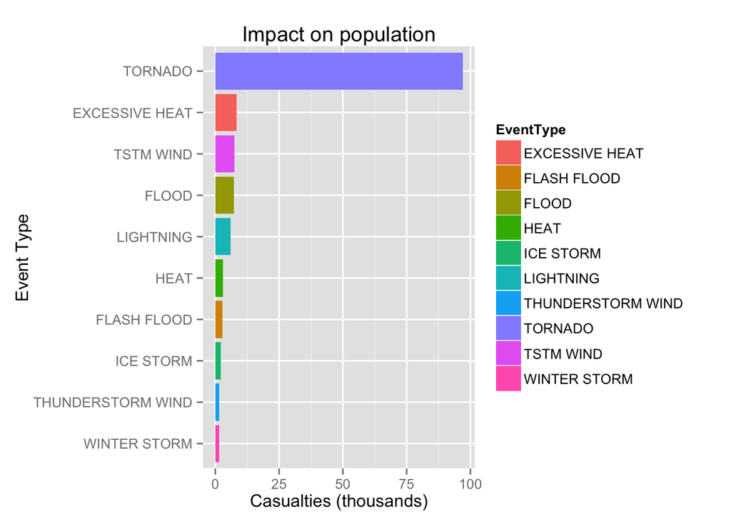

```r
ggplot(casualties1, aes(x = reorder(EventType, Casualties), y = Casualties/1000, fill = EventType)) + coord_flip() + geom_bar(stat="identity") + xlab("Event Type") + ylab("Casualties (thousands)") + ggtitle("Impact on population")
```

### Impact of weather events on economy

The most harmful event on economy is FLOOD with the total damage 150.32 billions US dollars (the property damage 144.658 billions US dollars and the crop damage 5.662 billions US dollars)

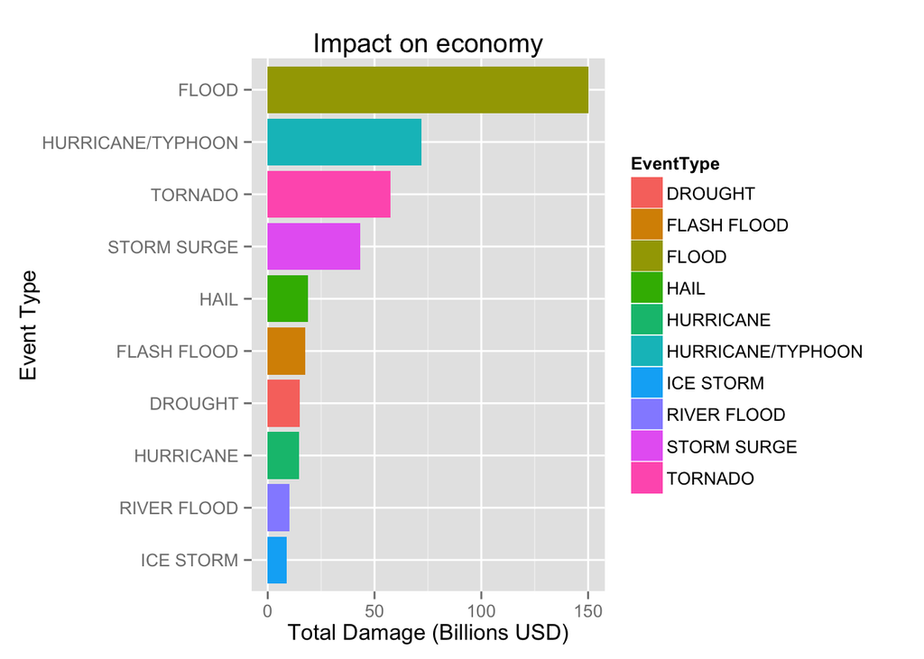

```r
ggplot(damage1, aes(x = reorder(EventType, Damage), y = Damage/billion, fill = EventType)) + coord_flip() + geom_bar(stat="identity") + xlab("Event Type") + ylab("Total Damage (Billions USD)") + ggtitle("Impact on economy")
```